# Aprendizaje Estadístico - (84:04)

Doctorado en Ingeniería Civil

Alejandro Verri Kozlowski

# Estimación no-paramétrica

1. En el archivo `buffalo.txt` se encuentran los datos que corresponden a la mediciones de cantidad de nieve caída (en pulgadas) en Buffalo en los inviernos de 1910/1911 a 1972/1973.Realizar un histograma para estos datos utilizando los parámetros por defecto.

```r
DT <- fread("data/buffalo.txt", sep=" ") |> transpose()
X <- DT$V1 |> sort()
summary(X)
```

```
##    Min. 1st Qu.  Median    Mean 3rd Qu.    Max.
##   25.00   64.50   79.60   80.30   97.65  126.40
```

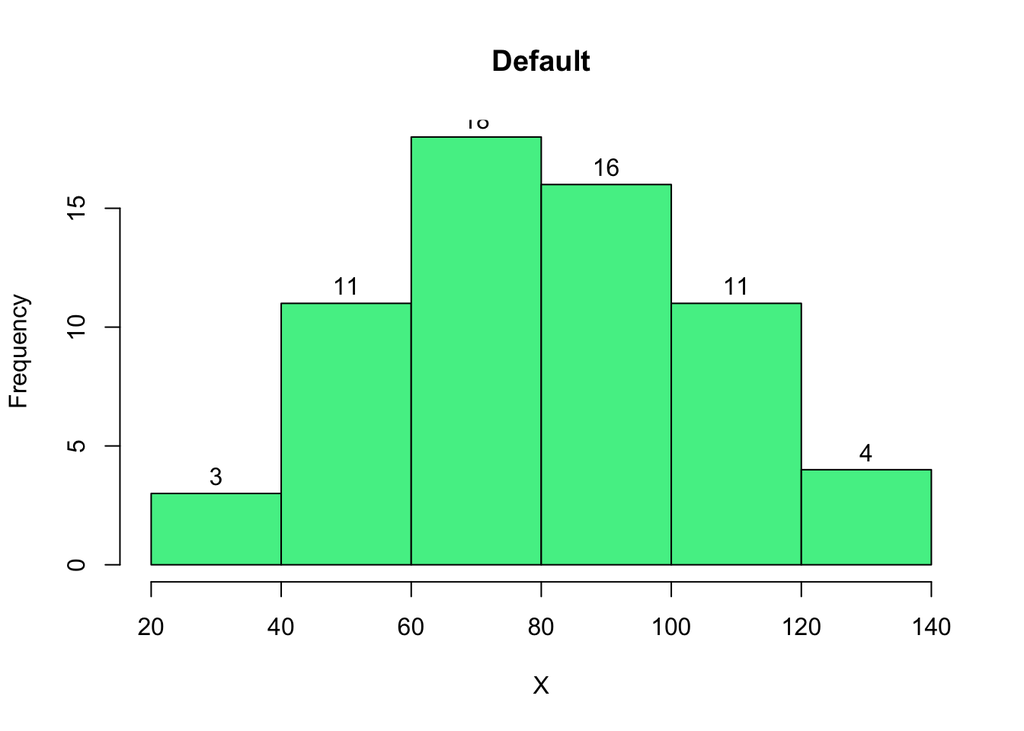

```r
hist(X, main="Default",col = "seagreen2",labels = TRUE)
```

Repetir eligiendo como puntos de corte las siguientes secuencias

1. De 20 a 130 con un paso de 10

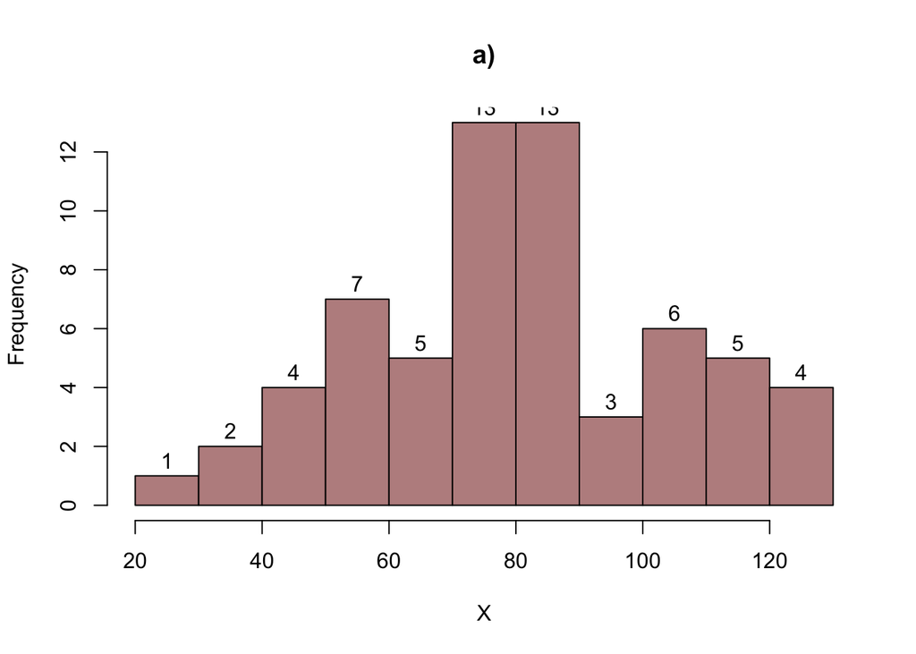

```r
BRK <- seq(from=20,to=130,by=10)
hist(X,breaks=BRK, main="a)", col = "rosybrown", labels = TRUE)
```

2. De 22 a 132 con un paso de 10

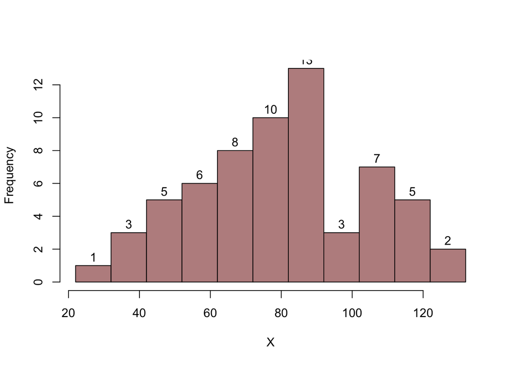

```r
BRK <- seq(from=22,to=132,by=10)
hist(X,breaks=BRK,main=NULL, col = "rosybrown", labels = TRUE)
```

3. De 24 a 134 con un paso de 10

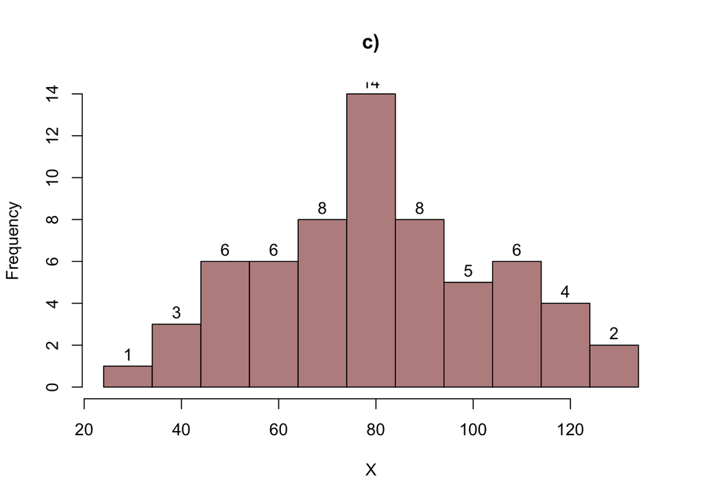

```r
BRK <- seq(from=24,to=134,by=10)
hist(X,breaks=BRK, main="c)", col = "rosybrown", labels = TRUE)
```

4. De 26 a 136 con un paso de 10

   Este histograma no puede visualizarse con las propiedades por defecto de la función `hist()`. El valor mínimo de `X` 25 queda fuera del límite inferior de los puntos de corte. PAra poder visualizar este histograma debe excluirse el primer punto del vector aleatorio $X$

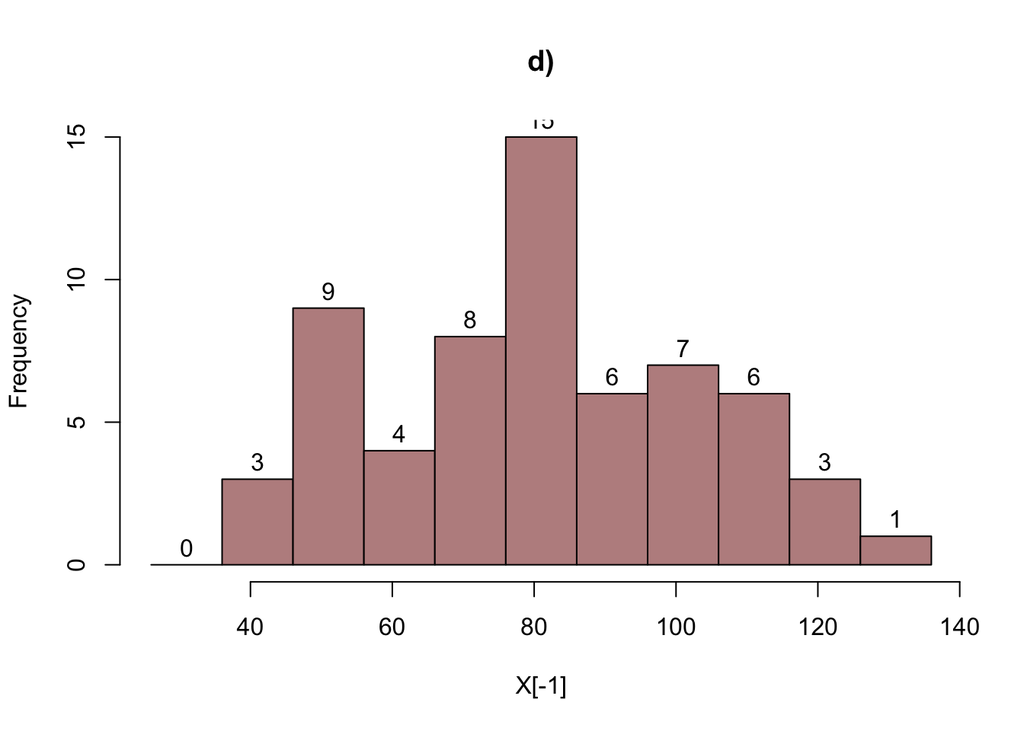

```r
BRK <- seq(from=26,to=136,by=10)
hist(X[-1],breaks=BRK, main="d)", col = "rosybrown", labels = TRUE)
```

2. Realizar un histograma para estas observaciones utilizando puntos de corte `(10, 20, 30, 40, 50, 60, 70, 80, 90, 100, 110, 120, 130)`. Comparar todos los histogramas obtenidos. ¿Tiene algún efecto la elección del punto inicial para estos datos?

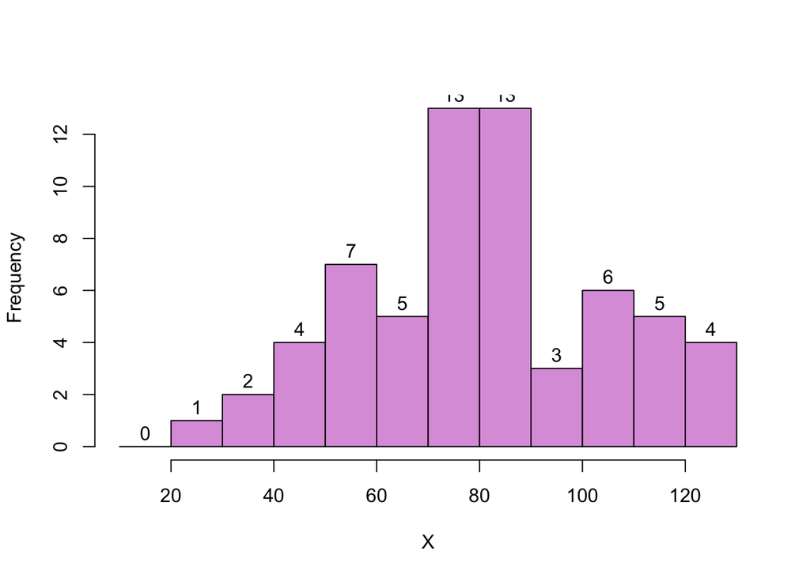

```r
BRK <- seq(from=10,to=130,by=10)
hist(X,breaks=BRK,main="", col = "plum", labels = TRUE)
```

> *Los histogramas con el mismo ancho de contenedor $h$ (binwidth) son diferentes y dependen fuertemente de la elección del origen $x_0$. Para un mismo $h$, la elección del punto inicial $x_0$ cambia completamente la forma (distribución de frecuencias) del histograma.*
3. Sea $X$ la cantidad de nieve caída en un invierno en Buffalo. Implementar una función que dados los valores $x$, $h$ y un conjunto de datos $X$, permita estimar a $P[X \in (x-h,x+h)] = P[x-h \leq X \leq x+h]$ para cada valor x.

> *Solución: Si $X$ es una V.A.C, la probabilidad de $X$ esté comprendida en el intervalo abierto $(x-h,x+h)$ puede estimarse mediante*

$$P[X \in (x-h,x+h)] \approx n^{-1} \sum_{i=1}^{n} \pmb{I}[X_i \in (x-h,x+h) ]$$

> *donde $\pmb{I}[X_i \in (x-h,x+h) ]$ es la función identificadora, que devuelve `1` si $X_i$ pertenece al intervalo y `0` de otro modo. La función `Px.h (x,X,h)` permite estimar la expresión anterior, tanto para valores de $x$ escalares, como así también asumiendo $x=X$ y calculando las probabilidades (densidades) de todos los puntos del intervalo*

```r
Px.h <- function(x,X,h){
  n <- length(X)
  sapply(x, function(t){sum(X>(t-h) &  X<(t+h))/n})}
# Chequear con Jemina los intervalos abiertos
```

4. Calcular la estimación de la probabilidad definida en el ítem anterior para cada valor x de la muestra usando $h$ 10, 20 y 30.

> *La tabla siguiente muestra las probabilidades estimadas mediante la función `Px.h (x,X,h)` para los 10 primeros valores del vector `X`*

```r
TABLE <- data.table(
  "x[i]"=X,
  "Px(h=10)"=Px.h(x=X,X=X,h=10) |> round(digits = 4),
  "Px(h=20)"=Px.h(x=X,X=X,h=20) |> round(digits = 4),
  "Px(h=30)"=Px.h(x=X,X=X,h=30)|> round(digits = 4)
)
head(TABLE,10) |> flextable()
```

| x[i] | Px(h=10) | Px(h=20) | Px(h=30) |
| --- | --- | --- | --- |
| 25.0 | 0.0159 | 0.0635 | 0.1746 |
| 39.8 | 0.0952 | 0.2222 | 0.3016 |
| 39.9 | 0.0952 | 0.2222 | 0.3016 |
| 40.1 | 0.0952 | 0.2222 | 0.3016 |
| 46.7 | 0.1905 | 0.2698 | 0.4127 |
| 49.1 | 0.2063 | 0.2698 | 0.4762 |
| 49.6 | 0.2063 | 0.2857 | 0.4921 |
| 51.1 | 0.1746 | 0.3016 | 0.5238 |
| 51.6 | 0.1746 | 0.3333 | 0.5238 |
| 53.5 | 0.1746 | 0.3651 | 0.5714 |

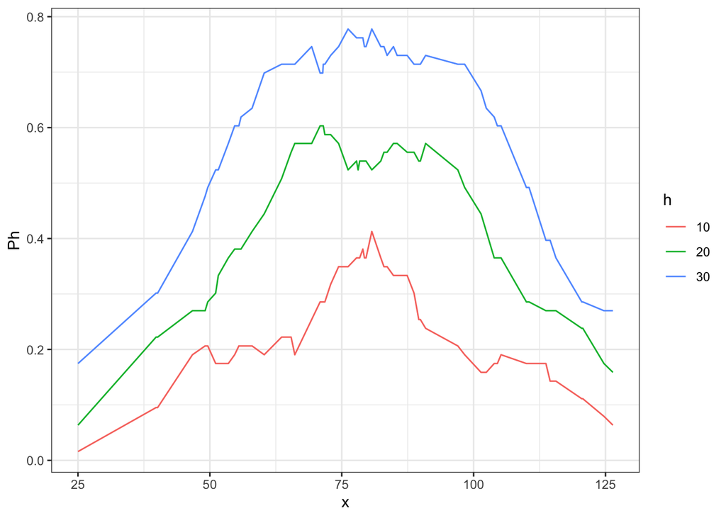

```r
DATA <- rbindlist(use.names = TRUE,l=list(
  data.table(h=10,x=X,Ph=Px.h(x=X,X=X,h=10)),
  data.table(h=20,x=X,Ph=Px.h(x=X,X=X,h=20)),
  data.table(h=30,x=X,Ph=Px.h(x=X,X=X,h=30)))
)
ggplot(DATA[,.(x,Ph,h=as.factor(h))], aes(x=x, y=Ph, fill=h, color=h)) + geom_line() +  theme_bw()
```

5. Implementar una función `densidad.est.parzen()` que dados un conjunto de datos, una ventana `h` y un punto `x` y devuelva $fh(x)$, el valor de la estimación de la densidad $f$ en el punto $x$, utilizando el núcleo uniforme (también llamado rectangular).

> *Se puede demostrar que una estimación de la densidad $\hat{f}_h(x)$ en un punto $x$ puede obtenerse a partir de la probabilidad $P[X \in (x-h,x+h)]$ según*

$$\hat{f_h}(x) \approx \frac{1}{2 h n} \sum_{i=1}^{n} \pmb{I}[X_i \in (x-h,x+h) ]$$

> *Si se efectúa un cambio de variable $t = (x-X_i)/h$ la función indicadora queda definida como: $\pmb{I}[X_i \in (x(t)-h,x(t)+h) ] = \pmb{I}[-1<t<+1]$*. Si definimos una función *núcleo* como $K(t)=1/2 \ \pmb{I}[-1<t<+1]$, el estimador de densidad puede escribirse en términos de dicha función como:_

$$\hat f_h(x) \approx \frac{1}{h n} \sum_{i=1}^{n} K \left( \frac{x-X_i}{h} \right)$$

> *A partir de esta definición, la siguiente rutina implementa la función del núcleo uniforme Ku(u)y el estimador de densidad `densidad.est.parzen`*

```r
Ku <- function(u){  1/2*(u > -1 &  u < +1)}
densidad.est.parzen <- function(x,X,h){
  n <- length(X)
  sapply(x, function(xi){sum(Ku((xi-X))/h)/(n*h)})}
```

6. Con la función `densidad.est.parzen()` implementada, estimar la densidad f en el intervalo `(25,126.4)` (mínimo y máximo de las observaciones) sobre una grilla de 200 puntos equiespaciados para `h = 10, 20, 30`. Graficar las estimaciones obtenidas sobre un mismo gráfico.

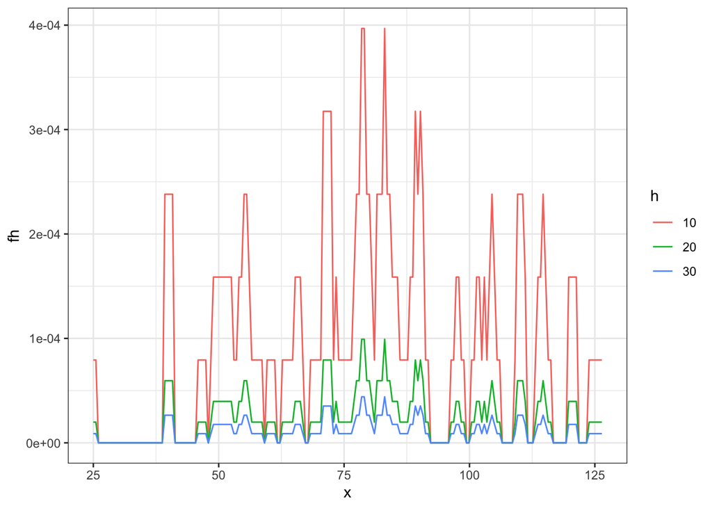

```r
xgrid <- seq(from=25,to=126.4,length.out=200)

DATA <- rbindlist(use.names = TRUE,l=list(
  data.table(h=10,x=xgrid,fh=densidad.est.parzen(x=xgrid,X=X,h=10)),
  data.table(h=20,x=xgrid,fh=densidad.est.parzen(x=xgrid,X=X,h=20)),
  data.table(h=30,x=xgrid,fh=densidad.est.parzen(x=xgrid,X=X,h=30)))
)
ggplot(DATA[,.(x,fh,h=as.factor(h))]) + geom_line(aes(x=x, y=fh, color=h))+ theme_bw()
```

7. La función de R `density()` computa un estimador de la densidad utilizando núcleos a partir de un conjunto de datos y la evalúa en un conjunto de puntos intermedios. Mediante la función de R `density()` estimar la función de densidad $f_h(x)$ a partir de los datos de Buffalo utilizando el núcleo normal, el rectangular y el de Epanechnikov con ventana `h = 5`. Realizar un gráfico superponiendo las tres estimaciones de f y el histograma.

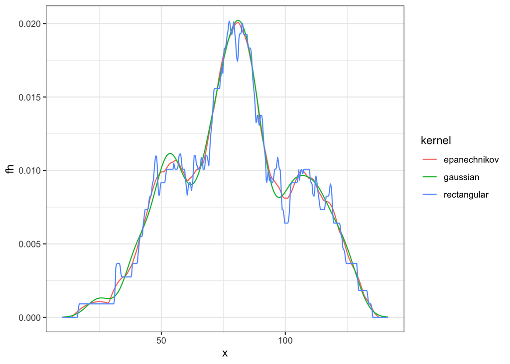

```r
G5 <- density(X,kernel = "gaussian",bw=5)
R5 <- density(X,kernel = "rectangular",bw=5)
E5 <- density(X,kernel = "epanechnikov",bw=5)

DATA <- rbindlist(use.names = TRUE,l=list(
  data.table(x=G5$x,fh=G5$y,kernel="gaussian",bw=G5$bw),
  data.table(x=R5$x,fh=R5$y,kernel="rectangular",bw=R5$bw),
 data.table(x=E5$x,fh=E5$y,kernel="epanechnikov",bw=E5$bw)
))
# ggplot(DATA, aes(color=kernel))  + geom_line(aes(x=x, y=fh))+ geom_histogram(aes(x=x),binwidth = 5) + theme_bw()

ggplot(DATA,aes(color=kernel)) + geom_line(aes(x=x,y=fh)) + theme_bw()
```

```r
DATA <- data.table()
for(KERNEL in c("gaussian","rectangular","epanechnikov")){
  for(BW in c(5,10,15,20,30,50)){
    D <-  density(X,kernel = KERNEL,bw=BW)
    DT <- data.table(x=D$x,fh=D$y,kernel = KERNEL,bw=as.factor(BW))
    DATA <- rbind(DATA,DT)
  }
}
```

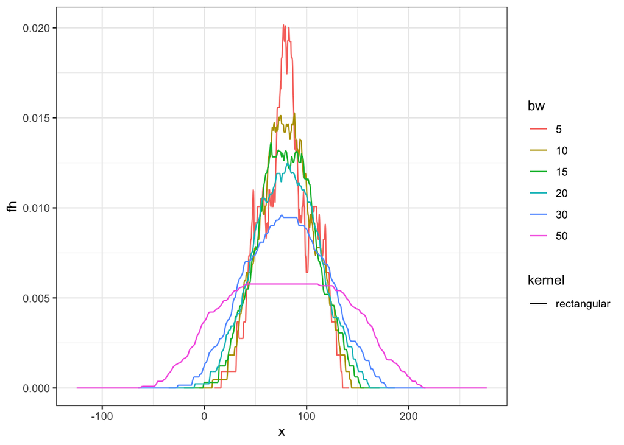

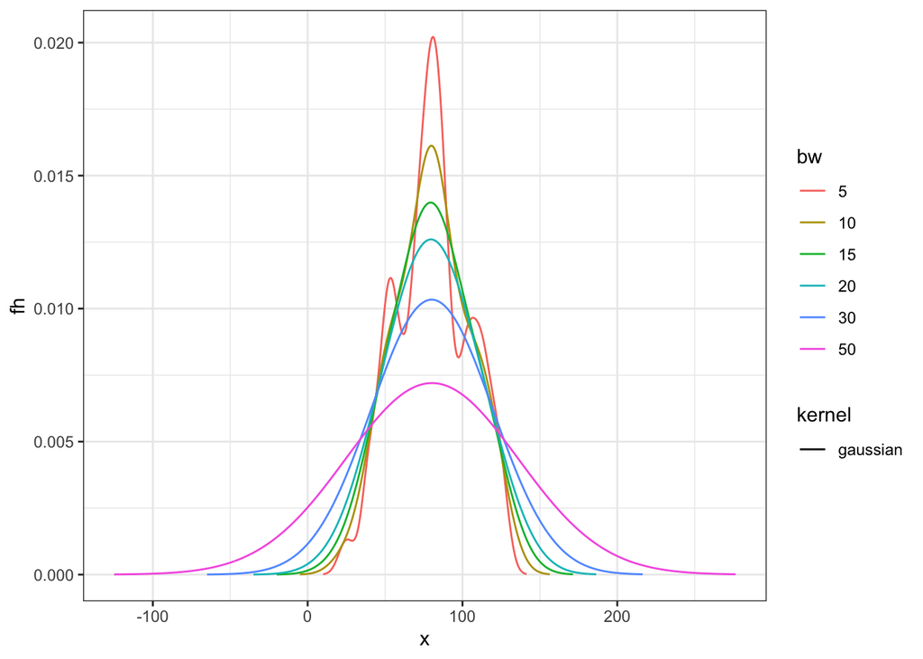

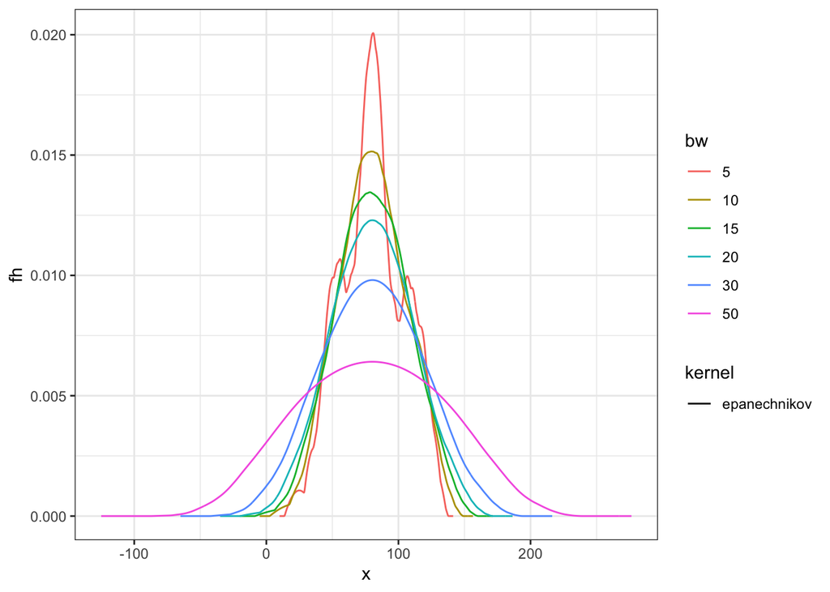